# Assessing the impact of songs on people in different ways based on the audio features

## Project done by: V.M.KARTHIK SAI

### Setup - Imported Spotify Dataset and Grammy Awards Dataset

### Source of Datasets - Kaggle - (https://www.kaggle.com/yamaerenay/spotify-dataset-19212020-160k-tracks) & (https://www.kaggle.com/unanimad/grammy-awards)

### Load packages if any using library(packagename)

```r
rm(list=ls())
library(dplyr)
```

```r
library(ggplot2)
```

### About the problem statement:

### I am assessing how different audio features of a song influence/impact people in different ways and find out what audio features were responsible for songs that got awards and for the ones that didn’t get an award by using two datasets.

### Chosen Datasets - Spotify Dataset and Grammy Awards Dataset

```r
setwd("C:/Users/KARSAI/Desktop/Data Analytics Project")
spotify=read.csv("data.csv")
grammy=read.csv("the_grammy_awards.csv")
genres=read.csv("data_by_genres.csv")
```

### Description of Dataset: Spotify Dataset - This dataset contains more than 160,000 songs collected from Spotify Web API with audio features of songs released in between 1921 and 2020. Grammy Awards Dataset - This dataset contains 6323 Grammy Awards presented by The Recording Academy to recognize achievements in the music industry.

### Basic commands to describe dataset:

### 1 - Structure

```r
str(spotify)
```

```
## 'data.frame':    169909 obs. of  19 variables:
##  $ acousticness    : num  0.995 0.994 0.604 0.995 0.99 0.995 0.956 0.988 0.995 0.846 ...
##  $ artists         : chr  "['Carl Woitschach']" "['Robert Schumann', 'Vladimir Horowitz']" "['Seweryn GoszczyÅ„ski']" "['Francisco Canaro']" ...
##  $ danceability    : num  0.708 0.379 0.749 0.781 0.21 0.424 0.444 0.555 0.683 0.674 ...
##  $ duration_ms     : int  158648 282133 104300 180760 687733 352600 136627 153967 162493 111600 ...
##  $ energy          : num  0.195 0.0135 0.22 0.13 0.204 0.12 0.197 0.421 0.207 0.205 ...
##  $ explicit        : int  0 0 0 0 0 0 0 0 0 0 ...
##  $ id              : chr  "6KbQ3uYMLKb5jDxLF7wYDD" "6KuQTIu1KoTTkLXKrwlLPV" "6L63VW0PibdM1HDSBoqnoM" "6M94FkXd15sOAOQYRnWPN8" ...
##  $ instrumentalness: num  0.563 0.901 0 0.887 0.908 0.911 0.435 0.836 0.206 0 ...
##  $ key             : int  10 8 5 1 11 6 11 1 9 9 ...
##  $ liveness        : num  0.151 0.0763 0.119 0.111 0.098 0.0915 0.0744 0.105 0.337 0.17 ...
##  $ loudness        : num  -12.4 -28.5 -19.9 -14.7 -16.8 ...
##  $ mode            : int  1 1 0 0 1 0 1 1 0 1 ...
##  $ name            : chr  "Singende Bataillone 1. Teil" "FantasiestÃ¼cke, Op. 111: PiÃ¹ tosto lento" "Chapter 1.18 - Zamek kaniowski" "Bebamos Juntos - Instrumental (Remasterizado)" ...
##  $ popularity      : int  0 0 0 0 1 0 0 0 0 0 ...
##  $ release_date    : chr  "1928" "1928" "1928" "1928-09-25" ...
##  $ speechiness     : num  0.0506 0.0462 0.929 0.0926 0.0424 0.0593 0.04 0.0474 0.127 0.954 ...
##  $ tempo           : num  118.5 84 107.2 108 62.1 ...
##  $ valence         : num  0.779 0.0767 0.88 0.72 0.0693 0.266 0.305 0.857 0.493 0.759 ...
##  $ year            : int  1928 1928 1928 1928 1928 1928 1928 1928 1928 1928 ...
```

```r
str(grammy)
```

```
## 'data.frame':    6323 obs. of  5 variables:
##  $ year    : int  1959 1959 1959 1959 1959 1959 1959 1959 1959 1959 ...
##  $ category: chr  "Album of the Year" "Best Album Cover" "Best Arrangement" "Best Classical Performance - Chamber Music (including Chamber Orchestra)" ...
##  $ nominee : chr  "The Music from Peter Gunn." "Only the Lonely" "The Music From Peter Gunn" "Beethoven: Quartet 130" ...
##  $ workers : chr  "Henry Mancini" "Frank Sinatra (art director)" "Henry Mancini (artist/arranger)" "The Hollywood String Quartet, Paul Shure (artist), Alvin Dinkin (artist), Eleanor Slatkin (artist) (as Eleanor "| __truncated__ ...
##  $ winner  : chr  "True" "True" "True" "True" ...
```

### 2 - Dimension

```r
dim(spotify)
```

```
## [1] 169909     19
```

```r
dim(grammy)
```

```
## [1] 6323    5
```

### 3 - Class

```r
class(spotify)
```

```
## [1] "data.frame"
```

```r
class(grammy)
```

```
## [1] "data.frame"
```

### 4 - Type

```r
typeof(spotify)
```

```
## [1] "list"
```

```r
typeof(grammy)
```

```
## [1] "list"
```

### 5 - Variables

```r
names(spotify)
```

```
##  [1] "acousticness"     "artists"          "danceability"     "duration_ms"
##  [5] "energy"           "explicit"         "id"               "instrumentalness"
##  [9] "key"              "liveness"         "loudness"         "mode"
## [13] "name"             "popularity"       "release_date"     "speechiness"
## [17] "tempo"            "valence"          "year"
```

```r
names(grammy)
```

```
## [1] "year"     "category" "nominee"  "workers"  "winner"
```

### 6 - Summary

```r
summary(spotify)
```

```
##   acousticness      artists           danceability     duration_ms
##  Min.   :0.0000   Length:169909      Min.   :0.0000   Min.   :   5108
##  1st Qu.:0.0945   Class :character   1st Qu.:0.4170   1st Qu.: 171040
##  Median :0.4920   Mode  :character   Median :0.5480   Median : 208600
##  Mean   :0.4932                      Mean   :0.5381   Mean   : 231406
##  3rd Qu.:0.8880                      3rd Qu.:0.6670   3rd Qu.: 262960
##  Max.   :0.9960                      Max.   :0.9880   Max.   :5403500
##      energy          explicit            id            instrumentalness
##  Min.   :0.0000   Min.   :0.00000   Length:169909      Min.   :0.000000
##  1st Qu.:0.2630   1st Qu.:0.00000   Class :character   1st Qu.:0.000000
##  Median :0.4810   Median :0.00000   Mode  :character   Median :0.000204
##  Mean   :0.4886   Mean   :0.08486                      Mean   :0.161937
##  3rd Qu.:0.7100   3rd Qu.:0.00000                      3rd Qu.:0.086800
##  Max.   :1.0000   Max.   :1.00000                      Max.   :1.000000
##       key            liveness         loudness            mode
##  Min.   : 0.000   Min.   :0.0000   Min.   :-60.000   Min.   :0.0000
##  1st Qu.: 2.000   1st Qu.:0.0984   1st Qu.:-14.470   1st Qu.:0.0000
##  Median : 5.000   Median :0.1350   Median :-10.474   Median :1.0000
##  Mean   : 5.201   Mean   :0.2067   Mean   :-11.370   Mean   :0.7086
##  3rd Qu.: 8.000   3rd Qu.:0.2630   3rd Qu.: -7.118   3rd Qu.:1.0000
##  Max.   :11.000   Max.   :1.0000   Max.   :  3.855   Max.   :1.0000
##      name             popularity     release_date        speechiness
##  Length:169909      Min.   :  0.00   Length:169909      Min.   :0.00000
##  Class :character   1st Qu.: 12.00   Class :character   1st Qu.:0.03490
##  Mode  :character   Median : 33.00   Mode  :character   Median :0.04500
##                     Mean   : 31.56                      Mean   :0.09406
##                     3rd Qu.: 48.00                      3rd Qu.:0.07540
##                     Max.   :100.00                      Max.   :0.96900
##      tempo           valence            year
##  Min.   :  0.00   Min.   :0.0000   Min.   :1921
##  1st Qu.: 93.52   1st Qu.:0.3220   1st Qu.:1957
##  Median :114.78   Median :0.5440   Median :1978
##  Mean   :116.95   Mean   :0.5321   Mean   :1977
##  3rd Qu.:135.71   3rd Qu.:0.7490   3rd Qu.:1999
##  Max.   :244.09   Max.   :1.0000   Max.   :2020
```

```r
summary(grammy)
```

```
##       year        category           nominee            workers
##  Min.   :1959   Length:6323        Length:6323        Length:6323
##  1st Qu.:1988   Class :character   Class :character   Class :character
##  Median :2002   Mode  :character   Mode  :character   Mode  :character
##  Mean   :1998
##  3rd Qu.:2011
##  Max.   :2019
##     winner
##  Length:6323
##  Class :character
##  Mode  :character
##
##
##
```

### My objectives:

### 1. To find out the number of positive and negative songs in the 20th century and 21st century based on the valence audio feature.

```r
spotify %>%
  filter(valence>0.5 & year<2001) %>%
  summarise(num_of_ps_20th_cent=n())
```

```
##   num_of_ps_20th_cent
## 1               74905
```

```r
spotify %>%
  filter(valence<=0.5 & year<2001) %>%
  summarise(num_of_ns_20th_cent=n())
```

```
##   num_of_ns_20th_cent
## 1               55348
```

```r
spotify %>%
  filter(valence>0.5 & year>=2001) %>%
  summarise(num_of_ps_21st_cent=n())
```

```
##   num_of_ps_21st_cent
## 1               19174
```

```r
spotify %>%
  filter(valence<=0.5 & year>=2001) %>%
  summarise(num_of_ns_21st_cent=n())
```

```
##   num_of_ns_21st_cent
## 1               20482
```

### Inference:

### Number of positive songs are greater than the number of negative songs in the 20th century.

### Number of negative songs are greater than the number of positive songs in the 21st century.

### 2. Visualizing the number of positive and negative songs in the 20th century and 21st century based on the valence audio feature.

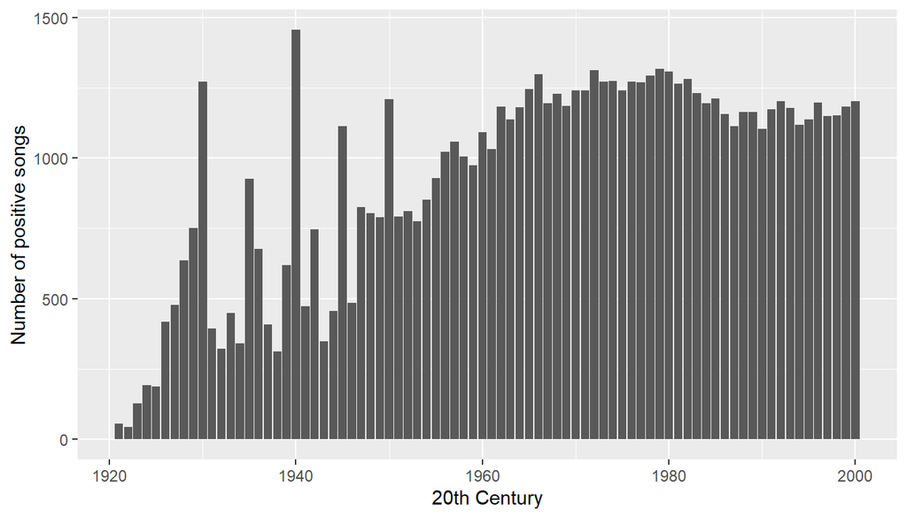

```r
ggplot(spotify %>% filter(valence>0.5 & year<2001) %>% select(year),aes(x=year,fill=year)) + geom_bar() +xlab("20th Century") +ylab("Number of positive songs")
```

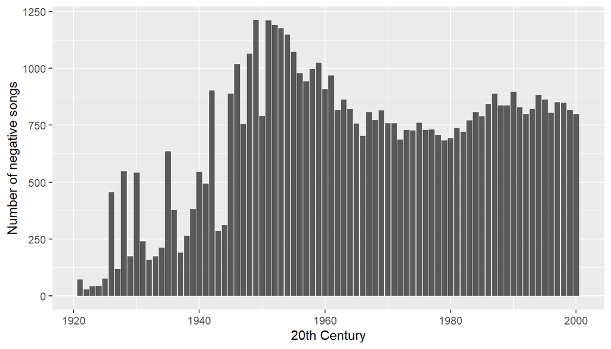

```r
ggplot(spotify %>% filter(valence<=0.5 & year<2001) %>% select(year),aes(x=year,fill=year)) + geom_bar() +xlab("20th Century") +ylab("Number of negative songs")
```

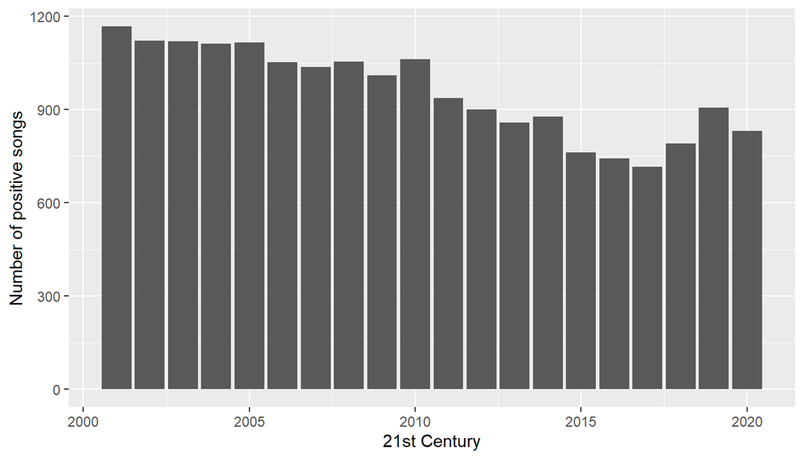

```r
ggplot(spotify %>% filter(valence>0.5 & year>=2001) %>% select(year),aes(x=year,fill=year)) + geom_bar() +xlab("21st Century") +ylab("Number of positive songs")
```

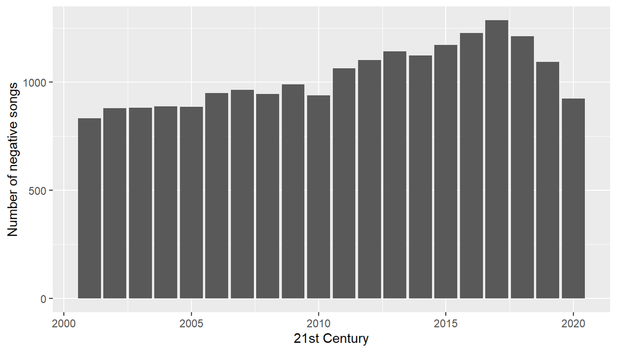

```r
ggplot(spotify %>% filter(valence<=0.5 & year>=2001) %>% select(year),aes(x=year,fill=year)) + geom_bar() +xlab("21st Century") +ylab("Number of negative songs")
```

### 3. To find out the percentage of songs with high energy that has got an award and for songs that has not got an award.

```r
newgrammy <- grammy
names(newgrammy)[names(newgrammy) == "nominee"] <- "name"
test<-merge(spotify,newgrammy,by="name")
c1<-test %>%
  filter(energy>0.5 & winner=="True") %>%
  summarise(count=n())
phet<-round(c1/2982*100,2) ##2982 is total number of songs with high energy
print(paste(phet,"%"))
```

```
## [1] "68.44 %"
```

### 618 songs from grammy awards dataset weren’t available in spotify dataset.

```r
c2<-test %>%
  filter(energy>0.5 & winner=="False") %>%
  summarise(count=n())
phef<-round(c2/2982*100,2)
print(paste(phef,"%"))
```

```
## [1] "31.56 %"
```

### Inference:

### There is a higher percentage of songs with high energy that has got an award than for songs with high energy that have not got an award.

### 4. To check if mode and valence are proportional to each other when saying a song is positive or negative.

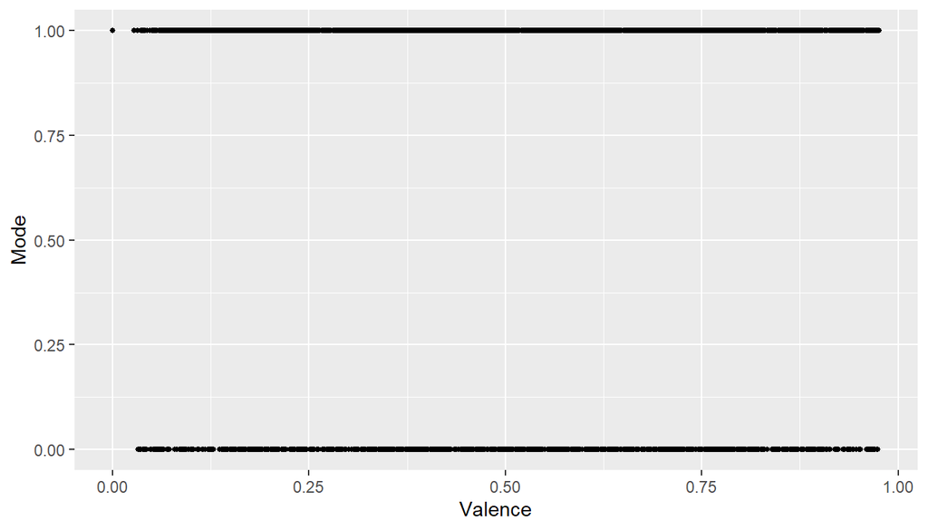

```r
ggplot(test, aes(x = valence, y = mode)) + geom_point(size = 1) + xlab("Valence") +ylab("Mode")
```

### Inference:

### On observing the plot, we can see that mode and valence are not proportional to each other.

### 5. To find out how many negative songs got an award based on the valence audio feature.

```r
test %>%
  filter(valence<=0.5 & winner=="True") %>%
  summarise(num_of_ns_got_award=n())
```

```
##   num_of_ns_got_award
## 1                2163
```

### 6. To find out the average value of danceability for songs that have not got an award.

```r
test %>%
  filter(winner=="False") %>%
  summarise(avgval=round(mean(danceability),2))
```

```
##   avgval
## 1   0.56
```

### 7. To visualize the difference in audio features values for songs that have got an award and for songs that have not got an award.

```r
col1<-test %>%
  filter(winner=="True")
```

```r
col2<-test %>%
  filter(winner=="False")
```

### Calculating the mean difference of each audio feature for the two category of songs (here category is of two types - songs that have got an award and songs that have not got an award).

```r
mean(col1$acousticness) - mean(col2$acousticness)
```

```
## [1] 0.1011651
```

```r
mean(col1$danceability) - mean(col2$danceability)
```

```
## [1] -0.02036752
```

```r
mean(col1$duration_ms) - mean(col2$duration_ms)
```

```
## [1] -2112.57
```

```r
mean(col1$energy) - mean(col2$energy)
```

```
## [1] -0.06462672
```

```r
mean(col1$explicit) - mean(col2$explicit)
```

```
## [1] -0.05355932
```

```r
mean(col1$instrumentalness) - mean(col2$instrumentalness)
```

```
## [1] 0.04386505
```

```r
mean(col1$key) - mean(col2$key)
```

```
## [1] -0.1040409
```

```r
mean(col1$liveness) - mean(col2$liveness)
```

```
## [1] 0.009522757
```

```r
mean(col1$loudness) - mean(col2$loudness)
```

```
## [1] -1.363129
```

```r
mean(col1$mode) - mean(col2$mode)
```

```
## [1] 0.03869787
```

```r
mean(col1$speechiness) - mean(col2$speechiness)
```

```
## [1] -0.009968681
```

```r
mean(col1$tempo) - mean(col2$tempo)
```

```
## [1] -3.067828
```

```r
mean(col1$valence) - mean(col2$valence)
```

```
## [1] 0.006076938
```

### My observations:

### 1. acousticness (A confidence measure from 0.0 to 1.0 of whether the track is acoustic) is lower for songs that didn’t get an award than for songs that got an award.

### Now visualizing the difference between the audio features of songs based on the above observations.

### acousticness and duration_ms (for songs that got an award)

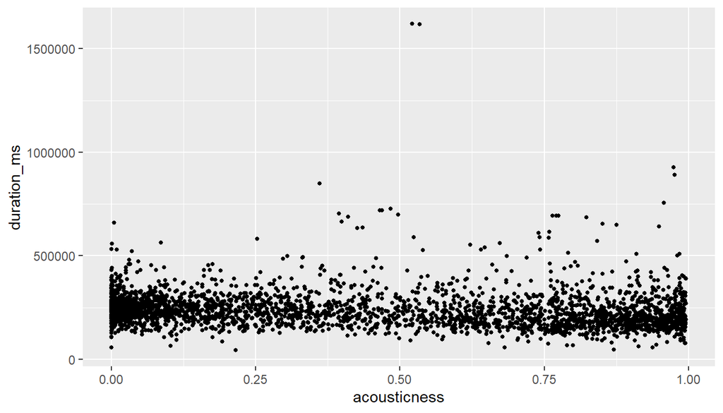

```r
ggplot(col1, aes(x=acousticness, y=duration_ms)) + geom_point(size=1) + xlab("acousticness") +ylab("duration_ms")
```

### acousticness and duration_ms (for songs that didn’t get an award)

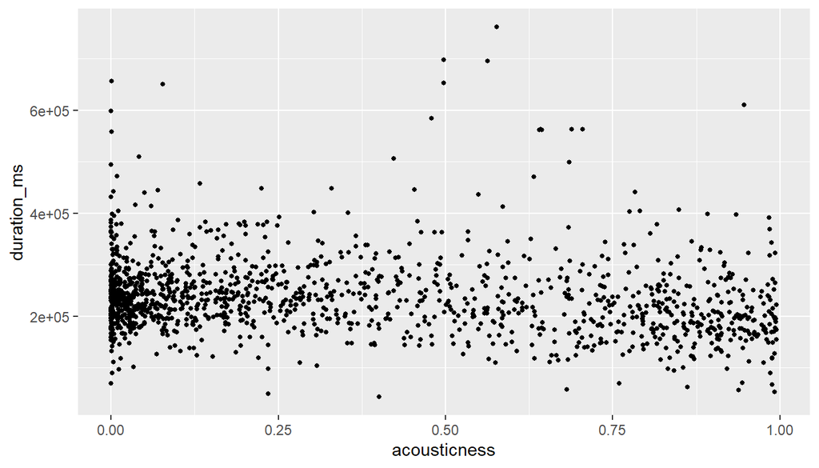

```r
ggplot(col2, aes(x=acousticness, y=duration_ms)) + geom_point(size=1) + xlab("acousticness") +ylab("duration_ms")
```

### explicit and tempo (for songs that got an award)

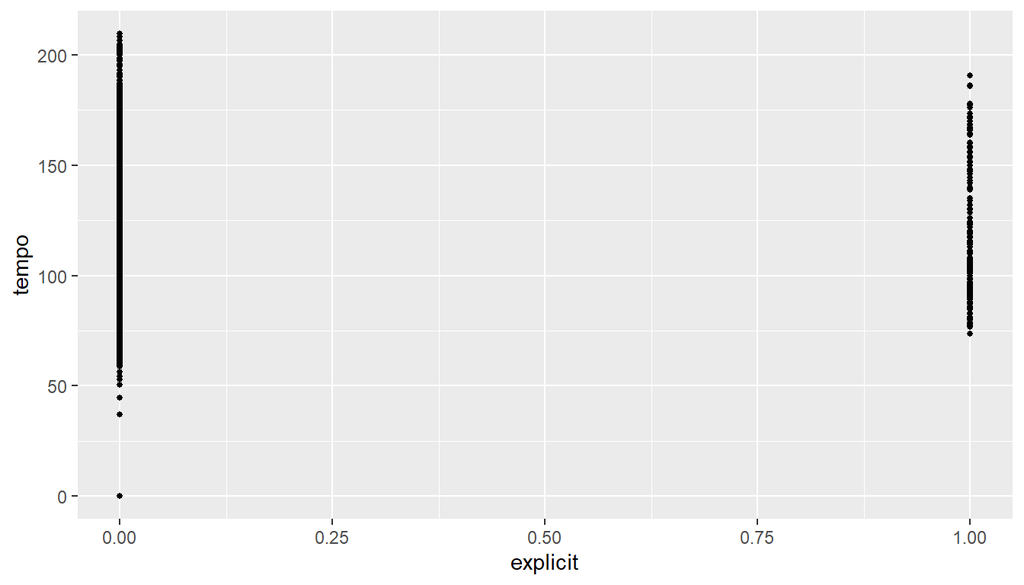

```r
ggplot(col1, aes(x=explicit, y=tempo)) + geom_point(size=1) + xlab("explicit") +ylab("tempo")
```

### explicit and tempo (for songs that didn’t get an award)

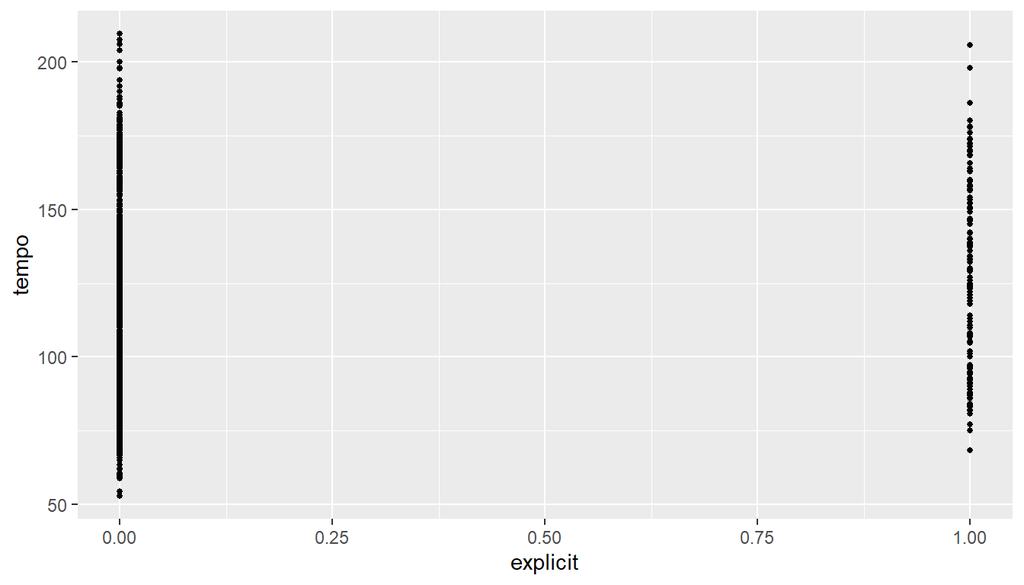

```r
ggplot(col2, aes(x=explicit, y=tempo)) + geom_point(size=1) + xlab("explicit") +ylab("tempo")
```

### key and loudness (for songs that got an award)

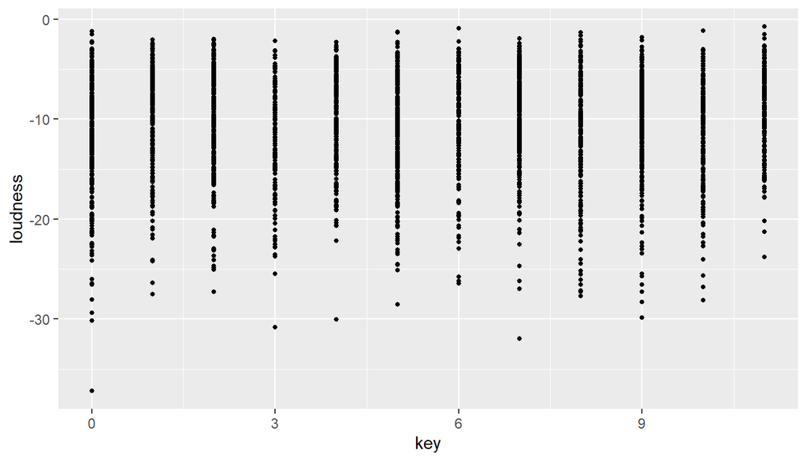

```r
ggplot(col1, aes(x=key, y=loudness)) + geom_point(size=1) + xlab("key") +ylab("loudness")
```

### key and loudness (for songs that didn’t get an award)

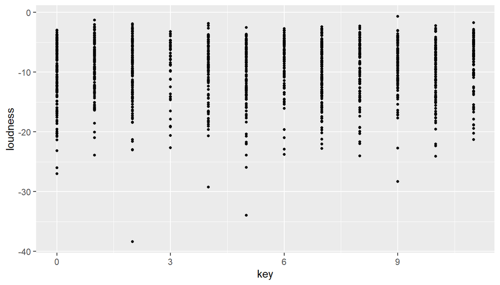

```r
ggplot(col2, aes(x=key, y=loudness)) + geom_point(size=1) + xlab("key") +ylab("loudness")
```

### 8. Checking which category of songs (here category is of two types - songs that have got an award and songs that have not got an award) has higher popularity than the other by looking at their average.

```r
mean(col1$popularity)
```

```
## [1] 41.27143
```

```r
mean(col2$popularity)
```

```
## [1] 46.21841
```

### Understanding from the previous observations:

### The reason why songs that didn’t get an award have been more popular than for songs that have got an award is because the majority of observations stated previously show that the songs that have got an award have lower audio feature values (duration_ms,explicit,tempo,loudness) than for songs that didn’t get an award.

### 9. To check what music genre has very high musical positiveness and what music genre has very high musical negativeness conveyed by a track.

```r
genres %>%
  filter(valence>0.95) %>%
  select(genres)
```

```
##                           genres
## 1                     concertina
## 2             cumbia santafesina
## 3                 deep punk rock
## 4                        euroska
## 5            japanese rockabilly
## 6             musique guadeloupe
## 7  musique pour enfant quebecois
## 8                   salsa cubana
## 9                    trio cubano
## 10                       zouglou
## 11                   zouk riddim
```

```r
genres %>%
  filter(valence<0.03) %>%
  select(genres)
```

```
##                   genres
## 1                   asmr
## 2         black 'n' roll
## 3        blackened crust
## 4            mindfulness
## 5  norwegian death metal
## 6                  shush
## 7           singing bowl
## 8          sound effects
## 9            white noise
## 10                  yoga
```

### 10. Finding and visualizing the popularity of songs that have got an award and popularity of songs that have not got an award in the 20th century and 21st century.

```r
col1 %>% filter(year.y<2001) %>% summarise(avgp=mean(popularity),avgy=mean(year.y))
```

```
##       avgp     avgy
## 1 37.59983 1983.259
```

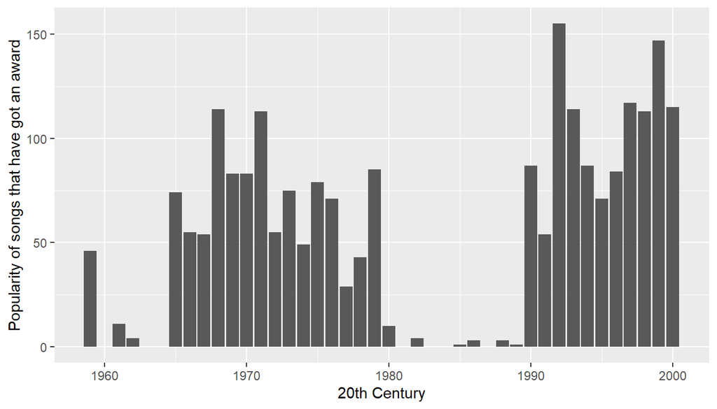

```r
ggplot(col1 %>% filter(year.y<2001) %>%select(popularity,year.y),aes(x=year.y,fill=popularity)) + geom_bar() +xlab("20th Century") +ylab("Popularity of songs that have got an award")
```

```r
col2 %>% filter(year.y<2001) %>% summarise(avgp=mean(popularity),avgy=mean(year.y))
```

```
##       avgp     avgy
## 1 42.96785 1988.723
```

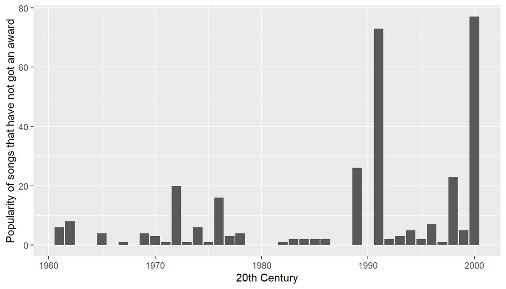

```r
ggplot(col2 %>% filter(year.y<2001) %>%select(popularity,year.y),aes(x=year.y,fill=popularity)) + geom_bar() +xlab("20th Century") +ylab("Popularity of songs that have not got an award")
```

```r
col1 %>% filter(year.y>2001) %>% summarise(avgp=mean(popularity),avgy=mean(year.y))
```

```
##       avgp     avgy
## 1 46.05069 2008.958
```

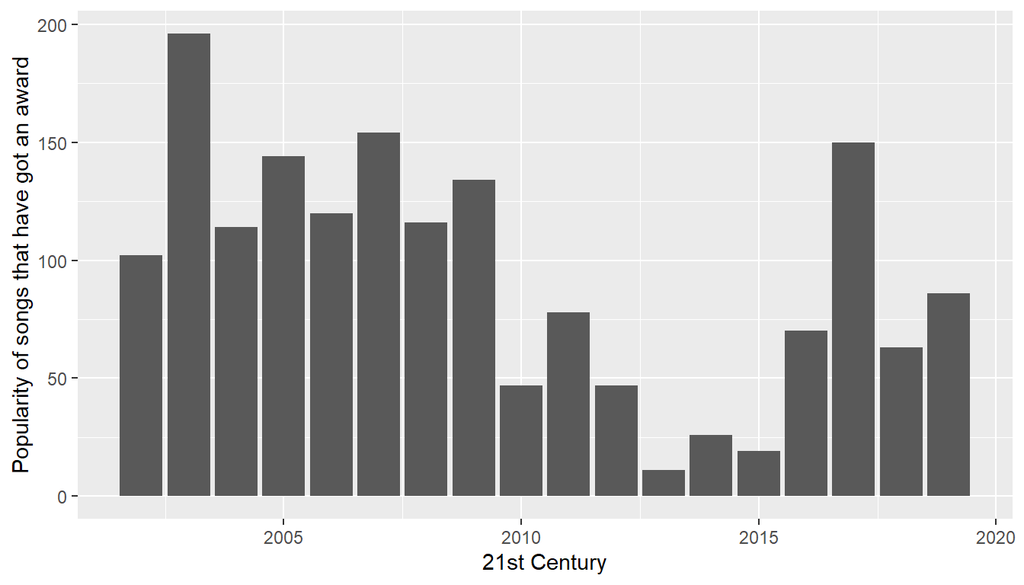

```r
ggplot(col1 %>% filter(year.y>2001) %>%select(popularity,year.y),aes(x=year.y,fill=popularity)) + geom_bar() +xlab("21st Century") +ylab("Popularity of songs that have got an award")
```

```r
col2 %>% filter(year.y>2001) %>% summarise(avgp=mean(popularity),avgy=mean(year.y))
```

```
##       avgp     avgy
## 1 47.13509 2009.208
```

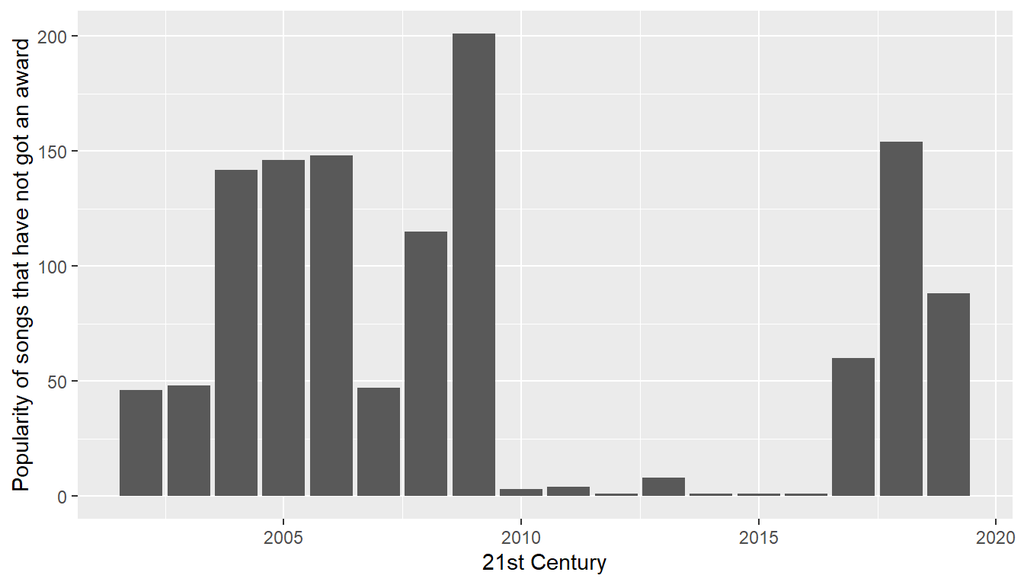

```r
ggplot(col2 %>% filter(year.y>2001) %>%select(popularity,year.y),aes(x=year.y,fill=popularity)) + geom_bar() +xlab("21st Century") +ylab("Popularity of songs that have not got an award")
```

### Inference:

### The popularity of songs that have not got an award is greater than the popularity of songs that have got an award in the 20th century.

### The popularity of songs that have not got an award is greater than the popularity of songs that have got an award in the 21st century.

### Conclusion:

### I have assessed how different audio features of a song influence/impact people in different ways and found out what audio features were responsible for songs that got awards and for the ones that didn’t get an award by using two datasets.

### Acknowledgements:

### I would like to thank Yamac Eren Ay and Raphael Fontes for providing the datasets on Kaggle.